# Métodos Computacionais para Estatística II

Lista 04

Daniel dos Santos

2018-05-26

## Questão 1

### a)

Intervalo de confiança para a média amostra (limitado inferiormente, variância conhecida)

```r
IC.media.esq <- function(x,conf,sigma){
  n <- length(x)
  x.barra <- mean(x)
  alpha <- 1-conf
  z <- qnorm(1-alpha)
  LI <- x.barra-z*sigma/sqrt(n)
  LS <- "Inf"
  cat("IC(mu,",100*conf,"%)=[",LI,";",LS,")")
}
IC.media.esq(rnorm(10),0.9,5)
```

```
## IC(mu, 90 %)=[ -1.903531 ; Inf )
```

### b)

Intervalo de confiança para a média amostral (limitado superiormente,variância conhecida)

```r
IC.media.dir <- function(x,conf,sigma){
  n <- length(x)
  x.barra <- mean(x)
  alpha <- 1-conf
  z <- qnorm(1-alpha)
  LI <- '-Inf'
  LS <- x.barra+z*sigma/sqrt(n)
  cat("IC(mu,",100*conf,"%)=(",LI,";",LS,"]")
}
IC.media.dir(rnorm(10),0.9,5)
```

```
## IC(mu, 90 %)=( -Inf ; 2.093009 ]
```

### c)

Intervalo de confiança para a média amostral (bilateral,variância conhecida)

```r
IC.media <- function(x,conf,sigma){
  n <- length(x)
  x.barra <- mean(x)
  alpha <- 1-conf
  z <- qnorm(1-alpha/2)
  LI <- x.barra-z*sigma/sqrt(n)
  LS <- x.barra+z*sigma/sqrt(n)
  cat("IC(mu,",100*conf,"%)=[",LI,";",LS,"]")
}
IC.media(rnorm(10),0.9,5)
```

```
## IC(mu, 90 %)=[ -2.658426 ; 2.543058 ]
```

### d)

Modifiquei um pouco a função anterior para fazer o que se pede

```r
IC.media <- function(x){
  n<- length(x)
  x.barra <- mean(x)
  alfa <- 0.1
  z1 <- qnorm(1-alfa/2)
  z2 <- qnorm(alfa/2)
  LS <- x.barra-z2*5/sqrt(n)
  LI <- x.barra-z1*5/sqrt(n)
  pertence <- ifelse(30< LS & 30> LI, 0,1)
  return(c(LimiteS = LS, LimiteI = LI, Media = x.barra, Pertence = pertence))
}
```

```r
mat.amostras <-  matrix(NA, ncol=1000, nrow=25)
for(i in 1:1000){
  mat.amostras[,i] <-  rnorm(25,30,5)
}
IC.amostral <- apply(mat.amostras,2,IC.media)
mean(IC.amostral['Pertence',])
```

```
## [1] 0.113
```

## Questão 2

Intervalo de confiança para a proporção amostral (bilateral e conservadora)

```r
IC.prop.conservative <- function(x,conf){
  n <- length(na.omit(x))
  p.chap <- mean(na.omit(x), na.rm = TRUE)
  alpha <- 1 - conf
  erro <- sqrt((.5*.5)/n)*qnorm(1-alpha/2)
  LI <- p.chap - erro
  LS <- p.chap + erro
  cat("IC(p,",100*conf,"%)=[",LI,";",LS,"]")
}
IC.prop.conservative(rbinom(10,1,1/2),0.9)
```

```
## IC(p, 90 %)=[ 0.3399258 ; 0.8600742 ]
```

## Questão 3

Importação dos dados

```r
setwd('C:\\Users\\Danie\\Documents\\IPC\\Estudos\\Metodos Com. Est. II\\Listas\\Lista 04')
baseSaude <- read.table("Base-saude.txt",na = '9',dec = ',',header = T) ; head(baseSaude)
```

```
##   Codigo  Datacol Sexo Idade Peso Estatura HIV Escol DST Tipo
## 1   AB01 14/10/15    1    20 61.2     1.60   1     3   1    2
## 2   AB02 09/02/16    0    30 60.0     1.55   0     5   0   NA
## 3   AB03 01/03/10    0    50 80.0     1.83   1     2   1    3
## 4   AB04 04/05/13    0    43 83.0     1.90   1    NA   1    2
## 5   AB05 20/05/14    0    22 75.3     1.75   0     2   1    3
## 6   AB06 30/01/11    1    15 70.2     1.70   1     6   0   NA
```

### a)

Intervalo de confiança para média amostral (bilateral, variância desconhecida)

```r
IC.media.desc <- function(x,conf){
  n <- length(na.omit(x))
  x.barra <- mean(na.omit(x))
  s <- sd(na.omit(x))
  alpha <- 1 - conf
  t <- qt(alpha/2,n-1,lower.tail = F)
  erro <- t*s/sqrt(n)
  LI <- x.barra - erro
  LS <- x.barra +erro
  cat("IC(mu,",100*conf,"%)=[",LI,";",LS,"]")
}
IC.media.desc(baseSaude$Peso,.97)
```

```
## IC(mu, 97 %)=[ 62.5888 ; 70.17672 ]
```

Interpretação: O intervalo possui 97% de chance de contar a média real da população.

### b)

Intervalo de confiança para média amostral (bilateral, variância desconhecida)  
Manipulando a tabela

```r
soroPos <- baseSaude %>%
  filter(HIV == 1)
soroPos$Estatura
```

```
##  [1] 1.60 1.83 1.90 1.70 1.65 1.62 1.55 1.70 1.66 1.60 1.83 1.90 1.70 1.65
## [15] 1.55 1.62 1.70 1.65 1.55 1.62 1.55
```

Aplicando a função criada anteriormente

```r
IC.media.desc(soroPos$Estatura,.95)
```

```
## IC(mu, 95 %)=[ 1.623345 ; 1.72237 ]
```

Interpretação: O intervalo possui 95% de chance de contar a média real da população.

### d)

Intervalo de confiança para média amostral (bilateral, variância desconhecida)  
Manipulando a tabela

```r
f_hiv0 <- baseSaude %>%
  filter(HIV == 0 & Sexo == 0)
f_hiv0$Idade
```

```
## [1] 30 22 39 60 NA 30 22 39
```

Aplicando a função criada anteriormente

```r
IC.media.desc(f_hiv0$Idade,.9)
```

```
## IC(mu, 90 %)=[ 24.88465 ; 44.2582 ]
```

Interpretação: O intervalo possui 90% de chance de contar a média real da população.

## Questão 4

Apenas precisamos criar a função

```r
IC.media.sex.group <- function(col,group,conf){
  f <- filter(baseSaude,Sexo == 0)
  m <- filter(baseSaude,Sexo == 1)
  f <- select(f,col)
  m <- select(m,col)
  if(group == 0){cat('Feminino - ') ; IC.media.desc(as.numeric(unlist(f)),conf)}
  if(group == 1){cat('Masculino - ') ; IC.media.desc(as.numeric(unlist(m)),conf)}
  if(group == 3){
    cat('Masculino - ') ; IC.media.desc(as.numeric(unlist(m)),conf)
    cat('\n Feminino - ') ; IC.media.desc(as.numeric(unlist(f)),conf)
  }
}
```

## Questão 5

Usando a função anterior para calcular os ICs

```r
IC.media.sex.group('Estatura',3,.95)
```

```
## Masculino - IC(mu, 95 %)=[ 1.590435 ; 1.647212 ]
##  Feminino - IC(mu, 95 %)=[ 1.636666 ; 1.81 ]
```

Interpretação: O intervalo possui 95% de chance de contar a média real da população.

## Questão 6

Criando função que calcula intervalo de confiança para variância amostral de uma população normal

```r
IC.var <- function(x,conf){
  n <- length(na.omit(x))
  s.dois <- var(na.omit(x))
  alpha <- 1 - conf
  chi1 <- qchisq(alpha/2,n-1,lower.tail = F)
  chi2 <- qchisq(1-alpha/2,n-1,lower.tail = F)
  LS <- s.dois*(n-1)/chi2
  LI <- s.dois*(n-1)/chi1
  cat("IC(sigma2,",100*conf,"%)=[",LI,";",LS,"]")
}
```

### a)

Fazendo uma consulta a tabela

```r
m.pos <- baseSaude %>%
  filter(Sexo ==1, HIV == 1)
IC.var(m.pos$Idade,0.9)
```

```
## IC(sigma2, 90 %)=[ 28.49649 ; 102.7197 ]
```

### b)

```r
IC.var(baseSaude$Estatura,.95)
```

```
## IC(sigma2, 95 %)=[ 0.007428475 ; 0.02157557 ]
```

### c)

```r
escolzero <- baseSaude %>%
  filter(HIV == 0)
IC.var(escolzero$Peso,.97)
```

```
## IC(sigma2, 97 %)=[ 39.39026 ; 483.1593 ]
```

## Questão 7

Importação dos dados

```r
dadosExame <- readRDS("exames-medicos.rds")
head(dadosExame)
```

```
##    LDL HDL glicose linfocitos
## 1 30.2 1.0    47.3         15
## 2 33.0 0.8    53.7          9
## 3 30.9 0.1    50.1         14
## 4 28.5 0.1    56.0         11
## 5 26.5 0.0    54.2         10
## 6 28.8 0.1    47.7          8
```

### a)

Gráfico quantil-quantil para verificar se há envidências de que a amostra vem de uma população normal.

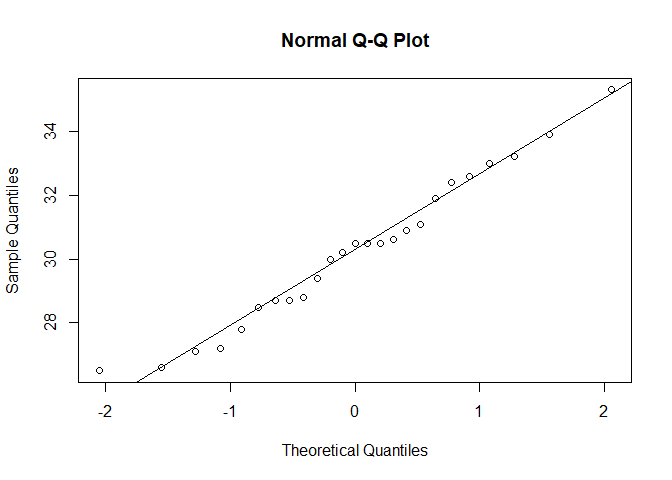

Gráfico quantil - quantil para LDL

Conclusão: Há evidências suficentes que mostram que a amostra de LDL veio de uma população normal

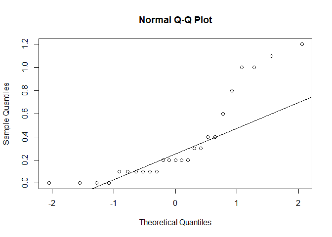

Gráfico quantil - quantil para HDL

Conclusão: Pelo gráfico quantil - quantil não há evidências suficentes que mostram que a amostra de HDL veio de uma população normal

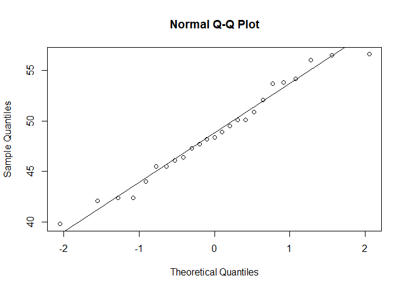

Gráfico quantil - quantil para glicose

Conclusão: Pelo gráfico quantil - quantil há evidências suficentes que mostram que a amostra de glicose veio de uma população normal

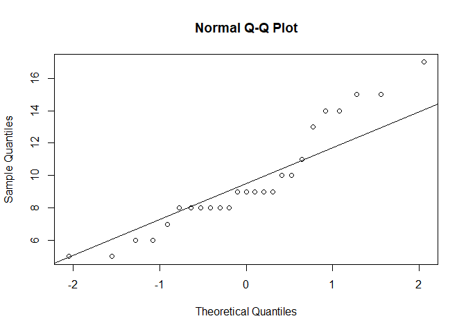

Gráfico quantil - quantil para linfocitos

Conclusão: Pelo gráfico quantil - quantil não há evidências suficentes que mostram que a amostra de linfocitos veio de uma população normal

### b)

```r
IC.media.desc(dadosExame$LDL,0.98)
```

```
## IC(mu, 98 %)=[ 29.06364 ; 31.40836 ]
```

Intervalo de confiança para média de glicose

```r
IC.media.desc(dadosExame$glicose,0.98)
```

```
## IC(mu, 98 %)=[ 46.36625 ; 51.08975 ]
```

### d)

Intervalo de confiança para variância de LDL

```r
IC.var(dadosExame$LDL,0.95)
```

```
## IC(sigma2, 95 %)=[ 3.373065 ; 10.70688 ]
```

Intervalo de confiança para variância de Glicose

```r
IC.var(dadosExame$glicose,0.95)
```

```
## IC(sigma2, 95 %)=[ 13.68889 ; 43.45165 ]
```

### e)

Fazendo uma consulta a tabela

```r
IC.prop.conservative(baseSaude.peso,0.95)
```

```
## IC(p, 95 %)=[ 0.8180219 ; 1.181978 ]
```

## Questão 8

### Parece muito o exercício anterior por isso não fiz, fui ver anime!

Importação dos dados

```r
dadosCol <- readRDS("colesterol.rds")
head(dadosCol)
```

```
##    LDL HDL
## 1 54.4 0.3
## 2 52.8 0.2
## 3 50.5 0.2
## 4 52.7 0.6
## 5 51.1 0.9
## 6 48.7 0.2
```